# Assignment02

张雨晴 16307130308

2019年3月23日

## 任务1

```r
cat("\014");rm(list=ls())
```

```r
setwd("C:/Users/Administrator/Desktop/data mining/知乎大V分析--作业/5. 如何优雅地成为知乎大V")
#读取文件路径

zhihu <- read.csv("zhihu.csv",header=TRUE,blank.lines.skip=F,sep=",")

#将integer类型的列转换成character
zhihu0<-zhihu
zhihu0$姓名 <- as.character(zhihu0$姓名)
zhihu0$专业 <- as.character(zhihu0$专业)
zhihu0$行业 <- as.character(zhihu0$行业)
zhihu0$公司 <- as.character(zhihu0$公司)
zhihu0$职业 <- as.character(zhihu0$职业)
zhihu0$毕业院校 <- as.character(zhihu0$毕业院校)
zhihu0$是否备注公众号 <- as.character(zhihu0$是否备注公众号)
summary(zhihu0)
```

```
##       序号           姓名                性别            回答数
##  Min.   :    5   Length:1918        Min.   :0.0000   Min.   :    1.0
##  1st Qu.: 3333   Class :character   1st Qu.:0.0000   1st Qu.:   21.0
##  Median : 7302   Mode  :character   Median :0.0000   Median :   64.0
##  Mean   : 7780                      Mean   :0.2096   Mean   :  209.7
##  3rd Qu.:11811                      3rd Qu.:0.0000   3rd Qu.:  183.0
##  Max.   :17518                      Max.   :2.0000   Max.   :16199.0
##      提问数            专栏数          分享数            点赞数
##  Min.   :   0.00   Min.   :0.000   Min.   :  0.000   Min.   :      1.0
##  1st Qu.:   0.00   1st Qu.:0.000   1st Qu.:  0.000   1st Qu.:    649.2
##  Median :   2.00   Median :1.000   Median :  0.000   Median :   3915.5
##  Mean   :  13.01   Mean   :0.804   Mean   :  4.647   Mean   :  25474.1
##  3rd Qu.:   7.00   3rd Qu.:1.000   3rd Qu.:  1.000   3rd Qu.:  18015.2
##  Max.   :1754.00   Max.   :8.000   Max.   :284.000   Max.   :1460757.0
##      感谢数           行业               公司               职业
##  Min.   :     1   Length:1918        Length:1918        Length:1918
##  1st Qu.:   128   Class :character   Class :character   Class :character
##  Median :   726   Mode  :character   Mode  :character   Mode  :character
##  Mean   :  4917
##  3rd Qu.:  3559
##  Max.   :250787
##    毕业院校             专业           是否备注公众号
##  Length:1918        Length:1918        Length:1918
##  Class :character   Class :character   Class :character
##  Mode  :character   Mode  :character   Mode  :character
##
##
##
##      关注数           被关注数
##  Min.   :    0.0   Min.   :     1
##  1st Qu.:   24.0   1st Qu.:   483
##  Median :   84.5   Median :  2240
##  Mean   :  237.4   Mean   : 16429
##  3rd Qu.:  217.2   3rd Qu.:  9360
##  Max.   :15837.0   Max.   :808142
```

## 任务2

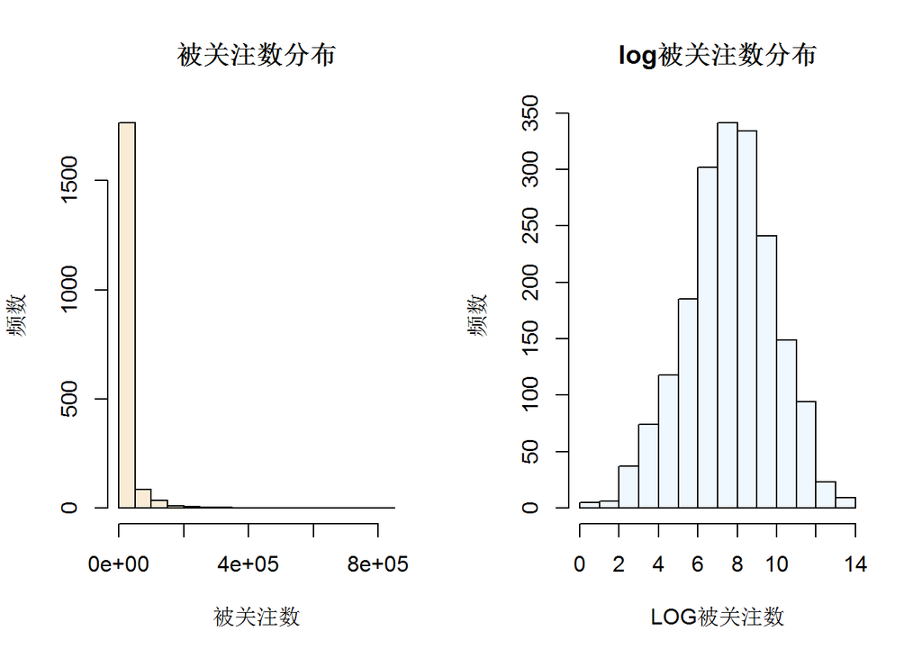

```r
zhihu$Logfans <- as.double(log((zhihu$被关注数)))
split.screen(c(1,2)) #分屏幕为左右两边

screen(1) #屏幕1预备输出
hist(zhihu$被关注数,
     main="被关注数分布",
     col="antiquewhite",
     xlab="被关注数",
     ylab="频数")
screen(2) #屏幕2预备输出
hist(zhihu$Logfans,
     main="log被关注数分布",
     col="aliceblue",
     xlab="LOG被关注数",
     ylab="频数")
```

## 任务3

### 3.1所在公司

```r
summary(zhihu$公司)[1:20]
```

```
##      阿里巴巴集团              腾讯              谷歌              百度
##                21                21                17                13
##              知乎          清华大学          Facebook        University
##                 9                 8                 6                 6
## 微软（Microsoft）       (University      ThoughtWorks          创业公司
##                 6                 5                 5                 5
##              网易          自由职业            NVIDIA          Research
##                 5                 5                 4                 4
##          北京大学            互联网        律师事务所            淘宝网
##                 4                 4                 4                 4
```

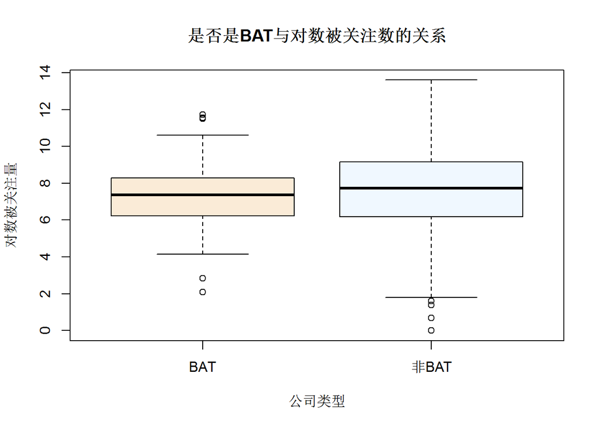

```r
zhihu$company <- as.character("非BAT")

zhihu$company[zhihu$公司=="百度"|zhihu$公司=="阿里巴巴集团"|zhihu$公司=="腾讯"]<-"BAT"

boxplot(Logfans ~company ,data = zhihu,
        col=c("antiquewhite","aliceblue"),
        xlab="公司类型",
        ylab="对数被关注量",
        main="是否是BAT与对数被关注数的关系")
```

**分析解读**  
令人有些意外的是：在BAT工作**并不**意味着可以获得较高的被关注量，但是BAT大佬们的粉丝数更为集中.

### 3.2所在职业

```r
summary(zhihu$职业)[1:20]
```

```
##      创始人         CEO  联合创始人    产品经理          of    (Google)
##         101          61          26          22          19          17
##      合伙人  前端工程师    产品总监      工程师         CTO    Software
##          15          15          12          12          11          11
##     Founder        打杂 (University    Research        博士  软件工程师
##          10          10           9           9           9           9
##  博士生在读        记者
##           8           8
```

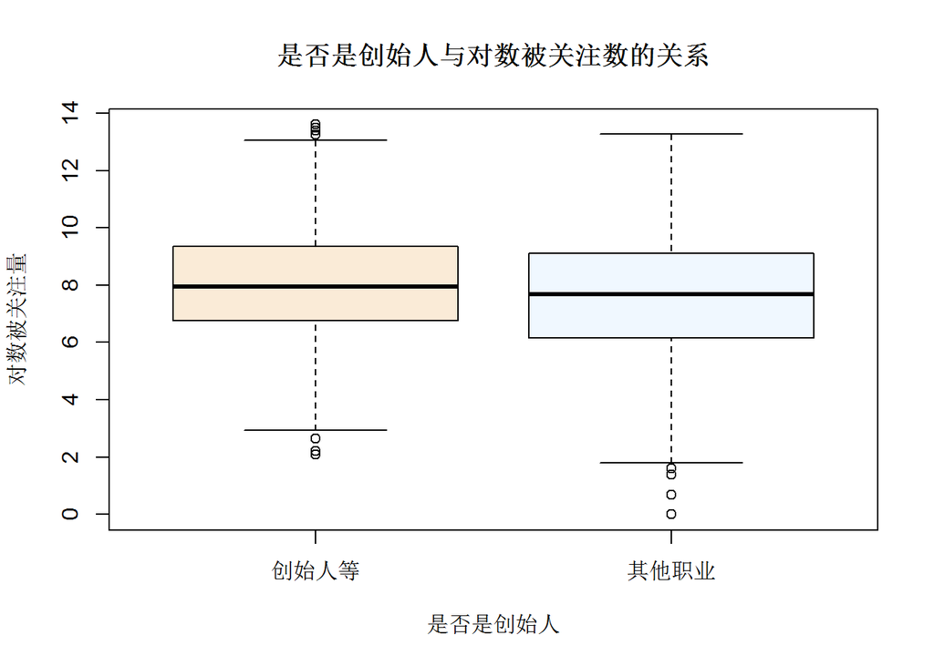

```r
zhihu$occupation <- as.character("其他职业")
zhihu$occupation[zhihu$职业=="创始人"|zhihu$职业=="联合创始人"|zhihu$职业=="CEO"|zhihu$职业=="合伙人"]<-"创始人等"
boxplot(Logfans ~ occupation ,data = zhihu,
        col=c("antiquewhite","aliceblue"),
        xlab="是否是创始人",
        ylab="对数被关注量",
        main="是否是创始人与对数被关注数的关系")
```

**分析解读**  
通过此图可以看出，创始人或CEO比其他职业获得的关注会更多。

### 3.3毕业院校

```r
summary(zhihu$毕业院校)[1:20]
```

```
##            北京大学            清华大学            浙江大学
##                  65                  63                  42
##            复旦大学          University        上海交通大学
##                  37                  34                  26
##            南京大学        华中科技大学            同济大学
##                  21                  17                  17
##            武汉大学        中国传媒大学    中山大学（SYSU）
##                  17                  16                  16
##        北京师范大学        哥伦比亚大学        中国人民大学
##                  15                  15                  15
##    北京航空航天大学 北京理工大学（BIT）            南开大学
##                  14                  13                  13
##        电子科技大学      卡内基梅隆大学
##                  12                  12
```

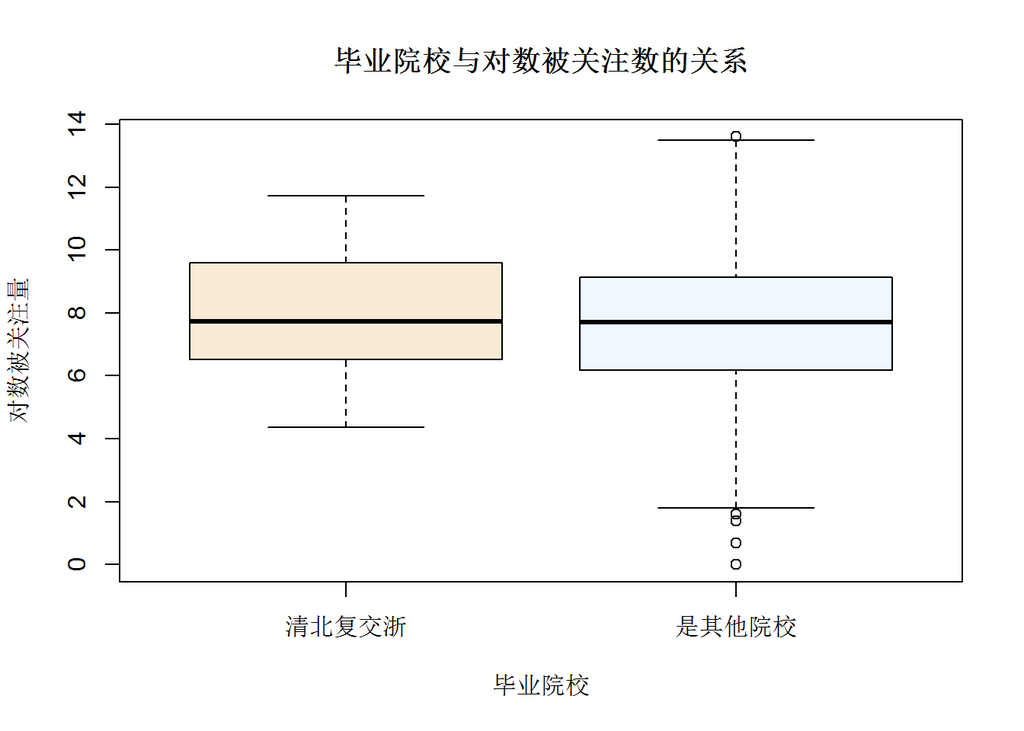

```r
zhihu$school <- as.character("是其他院校")
zhihu$school[zhihu$毕业院校 == c("北京大学","清华大学","浙江大学","复旦大学","上海交通大学")] <- "清北复交浙"
boxplot(Logfans ~ school ,data = zhihu,
        col = c("antiquewhite","aliceblue"),
        xlab="毕业院校",
        ylab = "对数被关注量",
        main = "毕业院校与对数被关注数的关系")
```

## 任务4

```r
summary(zhihu$提问数)
```

```
##    Min. 1st Qu.  Median    Mean 3rd Qu.    Max.
##    0.00    0.00    2.00   13.01    7.00 1754.00
```

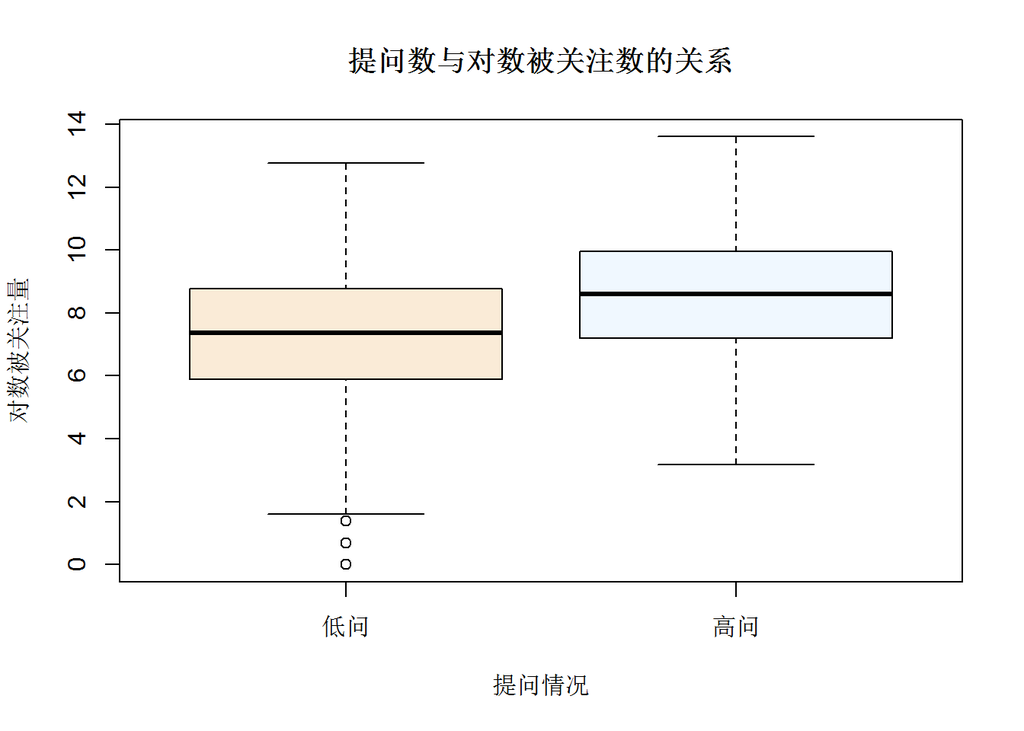

```r
q <- quantile(zhihu$提问数,0.75)
zhihu$提问数<-as.double(zhihu$提问数)
zhihu$question <- as.character("低问")
zhihu$question[zhihu$提问数 >= q] <- "高问"

boxplot(Logfans ~question ,data = zhihu,
        col = c("antiquewhite","aliceblue"),
        ylab = "对数被关注量",
        xlab = "提问情况",
        main = "提问数与对数被关注数的关系")
```

**分析解读**  
通过此图可以看出，提问数较高的人获得的关注普遍比低问者更多。

## 任务5

```r
zhihu$点赞比 <- as.character("高")
zhihu$点赞比[zhihu$点赞数/zhihu$回答数 <= 100] <- "低"
zhihu$感谢比<- as.character("高")
zhihu$感谢比[zhihu$感谢数/zhihu$回答数 <= 10] <- "低"
zhihu$分享比<- as.character("高")
zhihu$分享比[zhihu$分享数/zhihu$回答数 <= 0 ] <- "低"
```

## 任务6

```r
lm.sol <-lm(formula = Logfans ~ 性别 + company + occupation + school + 提问数 + 专栏数 + 回答数 + 感谢比 + 点赞比 +
     分享比, data = zhihu)
summary(lm.sol)
```

```
##
## Call:
## lm(formula = Logfans ~ 性别 + company + occupation + school +
##     提问数 + 专栏数 + 回答数 + 感谢比 + 点赞比 + 分享比, data = zhihu)
##
## Residuals:
##      Min       1Q   Median       3Q      Max
## -10.1045  -0.9443   0.0473   1.0214   5.3472
##
## Coefficients:
##                      Estimate Std. Error t value Pr(>|t|)
## (Intercept)         6.181e+00  3.122e-01  19.800  < 2e-16 ***
## 性别               -3.042e-01  8.028e-02  -3.790 0.000155 ***
## company非BAT        1.756e-01  2.144e-01   0.819 0.412731
## occupation其他职业 -2.605e-01  1.167e-01  -2.232 0.025707 *
## school是其他院校   -4.238e-01  2.086e-01  -2.032 0.042311 *
## 提问数              1.476e-03  5.177e-04   2.851 0.004401 **
## 专栏数              5.360e-01  3.824e-02  14.019  < 2e-16 ***
## 回答数              7.840e-04  6.311e-05  12.424  < 2e-16 ***
## 感谢比高            1.612e+00  9.503e-02  16.961  < 2e-16 ***
## 点赞比高            9.554e-01  9.980e-02   9.572  < 2e-16 ***
## 分享比高            6.730e-01  7.997e-02   8.415  < 2e-16 ***
## ---
## Signif. codes:  0 '***' 0.001 '**' 0.01 '*' 0.05 '.' 0.1 ' ' 1
##
## Residual standard error: 1.559 on 1907 degrees of freedom
## Multiple R-squared:  0.5169, Adjusted R-squared:  0.5144
## F-statistic:   204 on 10 and 1907 DF,  p-value: < 2.2e-16
```